# linear_regression

```r
cor(q12.dat)
```

```
##                tempo     users   tamanho utilizacao
## tempo      1.0000000 0.9923019 0.1423770  0.4149869
## users      0.9923019 1.0000000 0.0563720  0.4176533
## tamanho    0.1423770 0.0563720 1.0000000  0.2714265
## utilizacao 0.4149869 0.4176533 0.2714265  1.0000000
```

```r
confint(lm12)
```

```
##                  2.5 %     97.5 %
## (Intercept) -22.972704 192.401591
## users         1.803691   2.212326
```

```r
confint(lm12, level=0.99)
```

```
##                  0.5 %     99.5 %
## (Intercept) -71.977423 241.406309
## users         1.710714   2.305304
```

- 13. Em um servidor de arquivos, mediu-se a quantidade de memória usada com diferentes nú-meros de usuários simultâneos, conforme a tabela abaixo. Elabore um modelo de regressãosimples para esses dados que permita estimar o consumo de memória em função do númerode usuários, e interprete os resultados.

```r
q13.dat = read.table('q13.dat', header = TRUE)
q13.dat
```

```
##   users memory
## 1    10    529
## 2    20    700
## 3    30    598
## 4    40    766
## 5    50    640
## 6    60    641
## 7    70    884
## 8    80    782
```

```r
lm13 = lm(memory ~ users, q13.dat)
lm13
```

```
##
## Call:
## lm(formula = memory ~ users, data = q13.dat)
##
## Coefficients:
## (Intercept)        users
##     548.179        3.207
```

```r
summary(lm13)
```

```
##
## Call:
## lm(formula = memory ~ users, data = q13.dat)
##
## Residuals:
##    Min     1Q Median     3Q    Max
## -99.61 -55.57 -34.57  88.14 111.32
##
## Coefficients:
##             Estimate Std. Error t value Pr(>|t|)
## (Intercept)  548.179     69.702   7.865 0.000224 ***
## users          3.207      1.380   2.324 0.059164 .
## ---
## Signif. codes:  0 '***' 0.001 '**' 0.01 '*' 0.05 '.' 0.1 ' ' 1
##
## Residual standard error: 89.45 on 6 degrees of freedom
## Multiple R-squared:  0.4736, Adjusted R-squared:  0.3859
## F-statistic: 5.399 on 1 and 6 DF,  p-value: 0.05916
```

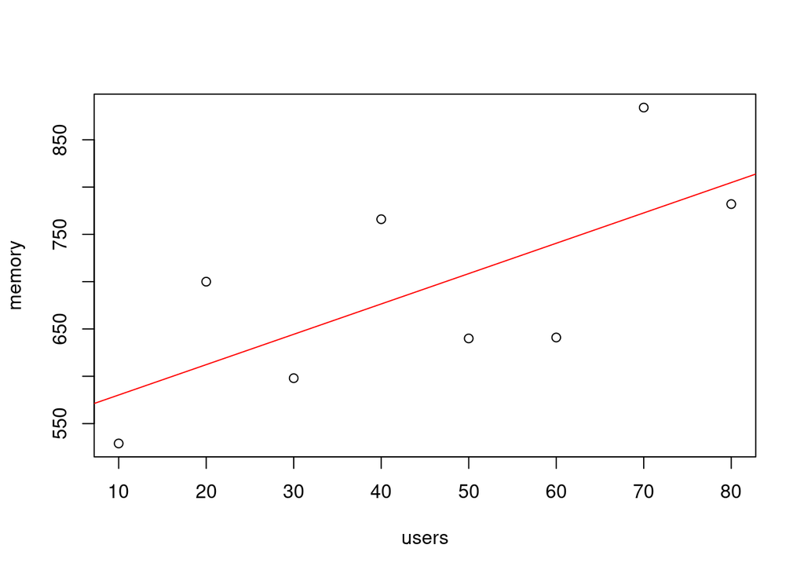

```r
plot(q13.dat) # ylim=c(0, 120)
abline(lm13, col='red')
```

```r
cor(q13.dat)
```

```
##            users    memory
## users  1.0000000 0.6882036
## memory 0.6882036 1.0000000
```

```r
confint(lm13)
```

```
##                   2.5 %     97.5 %
## (Intercept) 377.6245069 718.732636
## users        -0.1703309   6.584617
```

```r
confint(lm13, level=0.99)
```

```
##                  0.5 %     99.5 %
## (Intercept) 289.764310 806.592833
## users        -1.910222   8.324508
```

- 13 R: Bom, segundo os intervalos de confiança 95 e 99%, o modelo de regressão não é confiavel, pois o intervalo de confiança de memoria em função dos usuários não é significativo pois possui o 0 em seu intervalo. Além do que o p-value é maior do que o alfa = (1 - Nivel de confiança)
- 14. Em um centro de processamento de alto desempenho, é possível alocar um número fixo deprocessadores (até o limite de 128) para a execução de uma aplicação. Mediu-se o tempo deexecução de uma determinada aplicação com diferentes números de processadores, com osresultados mostrados na tabela abaixo.
- 1. Encontre um modelo de regressão linear para o tempo de execução em função do númerode processadores, e interprete os resultados.
- R: O tempo de execução em função ao número de processadores possui um modelo de regressão linear válido, pois o intervalo de confiança para 95 e 99% são significativos pois o intervalo não contem o valor 0, além disso o p-value é menor que o alfa para ambos os casos.

```r
q14.dat = read.table('q14.dat', header = TRUE)
q14.dat
```

```
##   processors time
## 1          1  842
## 2          2  773
## 3          6  697
## 4          8  678
## 5         11  611
## 6         12  630
```

```r
lm14 = lm(time ~ processors, q14.dat)
lm14
```

```
##
## Call:
## lm(formula = time ~ processors, data = q14.dat)
##
## Coefficients:
## (Intercept)   processors
##      829.79       -18.69
```

```r
summary(lm14)
```

```
##
## Call:
## lm(formula = time ~ processors, data = q14.dat)
##
## Residuals:
##       1       2       3       4       5       6
##  30.903 -19.403 -20.629  -2.242 -13.161  24.532
##
## Coefficients:
##             Estimate Std. Error t value Pr(>|t|)
## (Intercept)  829.790     19.456  42.650 1.81e-06 ***
## processors   -18.694      2.478  -7.545  0.00165 **
## ---
## Signif. codes:  0 '***' 0.001 '**' 0.01 '*' 0.05 '.' 0.1 ' ' 1
##
## Residual standard error: 25.18 on 4 degrees of freedom
## Multiple R-squared:  0.9344, Adjusted R-squared:  0.9179
## F-statistic: 56.93 on 1 and 4 DF,  p-value: 0.001653
```